# 成為初級資料分析師 | Python 機器學習

> Scikit-Learn 101

## 郭耀仁

> Simple and efficient tools for data mining and data analysis.

## 大綱

- Scikit-Learn 解決什麼問題
- Scikit-Learn 與獲取資料
- Scikit-Learn 與掌握資料
- Scikit-Learn 的 Estimator API

## Scikit-Learn 解決什麼問題

## 我們已經快速瀏覽過幾個端到端（End-to-end）專案，這些步驟包含：

- 獲取資料
- 掌握資料
- 探索資料
- 機器學習
- 溝通資料

## Scikit-Learn 在其中三個面向提供支援

- 獲取資料：`sklearn.datasets`
- 掌握資料：`sklearn.preprocessing`
- 機器學習：`sklearn` Estimators API

## 非常良善的 Scikit-Learn 設計

- 一致性（Consistency）
- 檢查性（Inspection）
- 不自行創建類別（Nonproliferation of classes）
- 模組化（Composition）
- 提供合理的預設參數（Sensible defaults）

## 一致性（Consistency）

所有 `sklearn` 物件具有相同而單純的介面：

- `Estimators`
  - `Transformers.fit_transform()`
  - `Predictors.fit()`、`Predictors.predict()`

## 檢查性（Inspection）

所有 `Estimators` 的參數都可以透過屬性 `.ATTR` 的方式檢視

## 不自行創建類別（Nonproliferation of classes）

資料格式都以 `ndarray` 儲存、參數都是 `str`、`int` 或 `float`

## 模組化（Composition）

多個 `Predictors` 或 `Transformers` 可以透過 `Pipeline` 與 `Meta-Estimator` 組裝起來

## 提供合理的預設參數（Sensible defaults）

在初始化 `Predictor` 的時候不需傳入參數即可創建基礎模型

## Scikit-Learn 與獲取資料

## 獲取資料的幾個常見管道

- `sklearn.datasets`
- 檔案
- Kaggle Datasets API
- 資料庫、網站爬蟲

## `sklearn.datasets`

- 使用 `load_` 函數讀入一個像是 `dict` 的物件
- 有五組 `key-value` 組合

```python
from sklearn.datasets import load_boston

boston = load_boston()
print(boston.keys())
```

```
dict_keys(['data', 'target', 'feature_names', 'DESCR', 'filename'])
```

```python
print(type(boston["data"]))
print(type(boston["target"]))
print(type(boston["feature_names"]))
print(type(boston["DESCR"]))
print(type(boston["filename"]))
```

```
<class 'numpy.ndarray'>
<class 'numpy.ndarray'>
<class 'numpy.ndarray'>
<class 'str'>
<class 'str'>
```

## 完整的 `sklearn.datasets` API

https://scikit-learn.org/stable/modules/classes.html#module-sklearn.datasets

## 檔案

使用 [Pandas I/O Tools](https://pandas.pydata.org/pandas-docs/stable/user_guide/io.html) 載入表格式資料為 `DataFrame`

```python
import pandas as pd

housing = pd.read_csv("https://kaggle-getting-started.s3-ap-northeast-1.amazonaws.com/house-prices/train.csv")
print(type(housing))
```

```
<class 'pandas.core.frame.DataFrame'>
```

## Kaggle Datasets API

- 安裝 Kaggle 模組
- 註冊 Kaggle 帳號
- 建立新的 API 憑證
- 參與三個 Getting Started 競賽
- 將 API 憑證（`kaggle.json`）置放在指定路徑
- 設定憑證讀寫權限
- 使用 Kaggle CLI
- （Optional）在 Google Colab 設定 Kaggle Data API

## 安裝 Kaggle 模組

```
# Run in command line
pip install kaggle
```

## 註冊 [Kaggle](https://www.kaggle.com/) 帳號

## 建立新的 API 憑證

- My Account
- Create New API Token

## 參與三個 Getting Started 競賽

- [Titanic](https://www.kaggle.com/c/titanic)
- [House Prices: Advanced Regression Techniques](https://www.kaggle.com/c/house-prices-advanced-regression-techniques)
- [Digit Recognizer](https://www.kaggle.com/c/digit-recognizer)

## 將 API 憑證（`kaggle.json`）置放在指定路徑

- UNIX：`/Users/USERNAME/.kaggle/kaggle.json`
- Windows：`C:\Users\USERNAME\.kaggle\kaggle.json`

## 設定憑證讀寫權限

```
# run in command line
chmod 600 /Users/USERNAME/.kaggle/kaggle.json
```

## 使用 Kaggle CLI

顯示資料集清單

```
kaggle datasets list
kaggle datasets list -s MNIST
```

## （Optional）在 Google Colab 設定 Kaggle Data API

```
!mkdir /root/.kaggle
import json
token = {"username": "YOUR-USERNAME", "key": "YOUR-KEY"}
with open('/root/.kaggle/kaggle.json', 'w') as file:
    json.dump(token, file)
!chmod 600 /root/.kaggle/kaggle.json
```

## Scikit-Learn 與掌握資料

## Scikit-Learn 如何表達資料

- 特徵矩陣（Feature Matrix）：$ m \times n $ 的 `ndarray`
- 目標向量（Target Vector）：$ m \times 1 $ 或 `(m,)` 的 `ndarray`

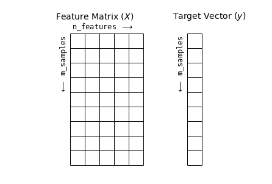

```python
get_feature_target_img()
```

## 隨堂練習：將三個 Getting Started 競賽的訓練資料（`train.csv`）分別擷取出特徵矩陣及目標向量

- [Titanic](https://www.kaggle.com/c/titanic) 的目標向量為 `Survived`，其餘變數為特徵矩陣
- [House Prices: Advanced Regression Techniques](https://www.kaggle.com/c/house-prices-advanced-regression-techniques) 的目標向量為 `SalePrice`，其餘變數為特徵矩陣
- [Digit Recognizer](https://www.kaggle.com/c/digit-recognizer) 的目標向量為 `label`，其餘變數為特徵矩陣

```python
# Titanic
print(y[:5])
print(X[:5])
```

```
[[0]
 [1]
 [1]
 [1]
 [0]]
[[1 3 'Braund, Mr. Owen Harris' 'male' 22.0 1 0 'A/5 21171' 7.25 nan 'S']
 [2 1 'Cumings, Mrs. John Bradley (Florence Briggs Thayer)' 'female' 38.0
  1 0 'PC 17599' 71.2833 'C85' 'C']
 [3 3 'Heikkinen, Miss. Laina' 'female' 26.0 0 0 'STON/O2. 3101282' 7.925
  nan 'S']
 [4 1 'Futrelle, Mrs. Jacques Heath (Lily May Peel)' 'female' 35.0 1 0
  '113803' 53.1 'C123' 'S']
 [5 3 'Allen, Mr. William Henry' 'male' 35.0 0 0 '373450' 8.05 nan 'S']]
```

```python
# House Prices: Advanced Regression Techniques
print(y[:5])
print(X[:5])
```

```
[[208500]
 [181500]
 [223500]
 [140000]
 [250000]]
[[1 60 'RL' 65.0 8450 'Pave' nan 'Reg' 'Lvl' 'AllPub' 'Inside' 'Gtl'
  'CollgCr' 'Norm' 'Norm' '1Fam' '2Story' 7 5 2003 2003 'Gable' 'CompShg'
  'VinylSd' 'VinylSd' 'BrkFace' 196.0 'Gd' 'TA' 'PConc' 'Gd' 'TA' 'No'
  'GLQ' 706 'Unf' 0 150 856 'GasA' 'Ex' 'Y' 'SBrkr' 856 854 0 1710 1 0 2
  1 3 1 'Gd' 8 'Typ' 0 nan 'Attchd' 2003.0 'RFn' 2 548 'TA' 'TA' 'Y' 0 61
  0 0 0 0 nan nan nan 0 2 2008 'WD' 'Normal']
 [2 20 'RL' 80.0 9600 'Pave' nan 'Reg' 'Lvl' 'AllPub' 'FR2' 'Gtl'
  'Veenker' 'Feedr' 'Norm' '1Fam' '1Story' 6 8 1976 1976 'Gable'
  'CompShg' 'MetalSd' 'MetalSd' 'None' 0.0 'TA' 'TA' 'CBlock' 'Gd' 'TA'
  'Gd' 'ALQ' 978 'Unf' 0 284 1262 'GasA' 'Ex' 'Y' 'SBrkr' 1262 0 0 1262 0
  1 2 0 3 1 'TA' 6 'Typ' 1 'TA' 'Attchd' 1976.0 'RFn' 2 460 'TA' 'TA' 'Y'
  298 0 0 0 0 0 nan nan nan 0 5 2007 'WD' 'Normal']
 [3 60 'RL' 68.0 11250 'Pave' nan 'IR1' 'Lvl' 'AllPub' 'Inside' 'Gtl'
  'CollgCr' 'Norm' 'Norm' '1Fam' '2Story' 7 5 2001 2002 'Gable' 'CompShg'
  'VinylSd' 'VinylSd' 'BrkFace' 162.0 'Gd' 'TA' 'PConc' 'Gd' 'TA' 'Mn'
  'GLQ' 486 'Unf' 0 434 920 'GasA' 'Ex' 'Y' 'SBrkr' 920 866 0 1786 1 0 2
  1 3 1 'Gd' 6 'Typ' 1 'TA' 'Attchd' 2001.0 'RFn' 2 608 'TA' 'TA' 'Y' 0
  42 0 0 0 0 nan nan nan 0 9 2008 'WD' 'Normal']
 [4 70 'RL' 60.0 9550 'Pave' nan 'IR1' 'Lvl' 'AllPub' 'Corner' 'Gtl'
  'Crawfor' 'Norm' 'Norm' '1Fam' '2Story' 7 5 1915 1970 'Gable' 'CompShg'
  'Wd Sdng' 'Wd Shng' 'None' 0.0 'TA' 'TA' 'BrkTil' 'TA' 'Gd' 'No' 'ALQ'
  216 'Unf' 0 540 756 'GasA' 'Gd' 'Y' 'SBrkr' 961 756 0 1717 1 0 1 0 3 1
  'Gd' 7 'Typ' 1 'Gd' 'Detchd' 1998.0 'Unf' 3 642 'TA' 'TA' 'Y' 0 35 272
  0 0 0 nan nan nan 0 2 2006 'WD' 'Abnorml']
 [5 60 'RL' 84.0 14260 'Pave' nan 'IR1' 'Lvl' 'AllPub' 'FR2' 'Gtl'
  'NoRidge' 'Norm' 'Norm' '1Fam' '2Story' 8 5 2000 2000 'Gable' 'CompShg'
  'VinylSd' 'VinylSd' 'BrkFace' 350.0 'Gd' 'TA' 'PConc' 'Gd' 'TA' 'Av'
  'GLQ' 655 'Unf' 0 490 1145 'GasA' 'Ex' 'Y' 'SBrkr' 1145 1053 0 2198 1 0
  2 1 4 1 'Gd' 9 'Typ' 1 'TA' 'Attchd' 2000.0 'RFn' 3 836 'TA' 'TA' 'Y'
  192 84 0 0 0 0 nan nan nan 0 12 2008 'WD' 'Normal']]
```

```python
# Digit Recognizer
print(y[:5])
print(X[:5])
```

```
[[1]
 [0]
 [1]
 [4]
 [0]]
[[0 0 0 ... 0 0 0]
 [0 0 0 ... 0 0 0]
 [0 0 0 ... 0 0 0]
 [0 0 0 ... 0 0 0]
 [0 0 0 ... 0 0 0]]
```

## 我們從 Kaggle Competition API 所獲得的資料會有兩個

- `train.csv`：標籤資料（labelled data）
- `test.csv`：無標籤資料（unlabelled data）

## 在維度 `n` 相差目標向量的有無

```python
import pandas as pd

housing_train = pd.read_csv("https://storage.googleapis.com/kaggle_datasets/House-Prices-Advanced-Regression-Techniques/train.csv")
housing_test = pd.read_csv("https://storage.googleapis.com/kaggle_datasets/House-Prices-Advanced-Regression-Techniques/test.csv")
print(housing_train.shape)
print(housing_test.shape)
```

```
(1460, 81)
(1459, 80)
```

## 根據監督式學習（Supervised Learning）的定義：

使用標籤資料（labelled data）訓練模型，再對無標籤資料（unlabelled data）預測

> 所以我們可以使用 `train.csv` 做訓練，然後對 `test.csv` 做預測對吧？

## 是，也不是

- （是）Kaggle 的 Getting Started 競賽允許一天上傳多次對答案
- （不是）生活中的專案應用「對答案」這件事情可能需要花費時間（例如：A/B Test 的實驗設計）

## 因此通常會將 `train.csv` 再切分成為訓練資料與驗證資料兩個部分

- 訓練（train）是標籤資料（labelled data）
- 驗證（validation）是**偽裝**成無標籤資料（unlabelled data）的標籤資料（labelled data）

[figure not shown]

## 使用 `sklearn.model_selection` 中的 `train_test_split()` 函數

雖然名稱是 `train_test_split()` 但其實是 **train validation split**

```python
import pandas as pd
from sklearn.model_selection import train_test_split

housing_train = pd.read_csv("https://storage.googleapis.com/kaggle_datasets/House-Prices-Advanced-Regression-Techniques/train.csv")
X = housing_train.drop("SalePrice", axis=1)
X_train, X_validation = train_test_split(X, test_size=0.33, random_state=42)
print("Before splitting:")
print(X.shape)
print("After splitting:")
print(X_train.shape, X_validation.shape)
```

```
Before splitting:
(1460, 80)
After splitting:
(978, 80) (482, 80)
```

```python
X.head()
```

|  | Id | MSSubClass | MSZoning | LotFrontage | LotArea | Street | Alley | LotShape | LandContour | Utilities | ... | ScreenPorch | PoolArea | PoolQC | Fence | MiscFeature | MiscVal | MoSold | YrSold | SaleType | SaleCondition |
| --- | --- | --- | --- | --- | --- | --- | --- | --- | --- | --- | --- | --- | --- | --- | --- | --- | --- | --- | --- | --- | --- |
| 0 | 1 | 60 | RL | 65.0 | 8450 | Pave | NaN | Reg | Lvl | AllPub | ... | 0 | 0 | NaN | NaN | NaN | 0 | 2 | 2008 | WD | Normal |
| 1 | 2 | 20 | RL | 80.0 | 9600 | Pave | NaN | Reg | Lvl | AllPub | ... | 0 | 0 | NaN | NaN | NaN | 0 | 5 | 2007 | WD | Normal |
| 2 | 3 | 60 | RL | 68.0 | 11250 | Pave | NaN | IR1 | Lvl | AllPub | ... | 0 | 0 | NaN | NaN | NaN | 0 | 9 | 2008 | WD | Normal |
| 3 | 4 | 70 | RL | 60.0 | 9550 | Pave | NaN | IR1 | Lvl | AllPub | ... | 0 | 0 | NaN | NaN | NaN | 0 | 2 | 2006 | WD | Abnorml |
| 4 | 5 | 60 | RL | 84.0 | 14260 | Pave | NaN | IR1 | Lvl | AllPub | ... | 0 | 0 | NaN | NaN | NaN | 0 | 12 | 2008 | WD | Normal |

5 rows × 80 columns

```python
X_train.head()
```

|  | Id | MSSubClass | MSZoning | LotFrontage | LotArea | Street | Alley | LotShape | LandContour | Utilities | ... | ScreenPorch | PoolArea | PoolQC | Fence | MiscFeature | MiscVal | MoSold | YrSold | SaleType | SaleCondition |
| --- | --- | --- | --- | --- | --- | --- | --- | --- | --- | --- | --- | --- | --- | --- | --- | --- | --- | --- | --- | --- | --- |
| 615 | 616 | 85 | RL | 80.0 | 8800 | Pave | NaN | Reg | Lvl | AllPub | ... | 0 | 0 | NaN | MnPrv | NaN | 0 | 5 | 2010 | WD | Abnorml |
| 613 | 614 | 20 | RL | 70.0 | 8402 | Pave | NaN | Reg | Lvl | AllPub | ... | 0 | 0 | NaN | NaN | NaN | 0 | 12 | 2007 | New | Partial |
| 1303 | 1304 | 20 | RL | 73.0 | 8688 | Pave | NaN | Reg | Lvl | AllPub | ... | 0 | 0 | NaN | NaN | NaN | 0 | 4 | 2006 | WD | Normal |
| 486 | 487 | 20 | RL | 79.0 | 10289 | Pave | NaN | Reg | Lvl | AllPub | ... | 0 | 0 | NaN | NaN | NaN | 0 | 6 | 2007 | WD | Normal |
| 561 | 562 | 20 | RL | 77.0 | 10010 | Pave | NaN | Reg | Lvl | AllPub | ... | 0 | 0 | NaN | NaN | NaN | 0 | 4 | 2006 | WD | Normal |

5 rows × 80 columns

```python
X_validation.head()
```

|  | Id | MSSubClass | MSZoning | LotFrontage | LotArea | Street | Alley | LotShape | LandContour | Utilities | ... | ScreenPorch | PoolArea | PoolQC | Fence | MiscFeature | MiscVal | MoSold | YrSold | SaleType | SaleCondition |
| --- | --- | --- | --- | --- | --- | --- | --- | --- | --- | --- | --- | --- | --- | --- | --- | --- | --- | --- | --- | --- | --- |
| 892 | 893 | 20 | RL | 70.0 | 8414 | Pave | NaN | Reg | Lvl | AllPub | ... | 0 | 0 | NaN | MnPrv | NaN | 0 | 2 | 2006 | WD | Normal |
| 1105 | 1106 | 60 | RL | 98.0 | 12256 | Pave | NaN | IR1 | Lvl | AllPub | ... | 0 | 0 | NaN | NaN | NaN | 0 | 4 | 2010 | WD | Normal |
| 413 | 414 | 30 | RM | 56.0 | 8960 | Pave | Grvl | Reg | Lvl | AllPub | ... | 0 | 0 | NaN | NaN | NaN | 0 | 3 | 2010 | WD | Normal |
| 522 | 523 | 50 | RM | 50.0 | 5000 | Pave | NaN | Reg | Lvl | AllPub | ... | 0 | 0 | NaN | NaN | NaN | 0 | 10 | 2006 | WD | Normal |
| 1036 | 1037 | 20 | RL | 89.0 | 12898 | Pave | NaN | IR1 | HLS | AllPub | ... | 0 | 0 | NaN | NaN | NaN | 0 | 9 | 2009 | WD | Normal |

5 rows × 80 columns

## 從前面觀察暸解 `train_test_split()` 函數做了什麼

- 對觀測值隨機排序（Shuffling）
- 依照 `test_size` 指定一列
- 將該列以上的資料分割為驗證資料集，該列以下的資料分割為訓練資料集

## 對觀測值隨機排序（Shuffling）

```python
import numpy as np

X_indices = np.array(X.index)
print(X_indices)
np.random.shuffle(X_indices)
print(X_indices)
```

```
[   0    1    2 ... 1457 1458 1459]
[ 924  855 1201 ... 1308  808  434]
```

## 對觀測值隨機排序（Shuffling）：加入 `random_state` 的設定

```python
import numpy as np

X_indices = np.array(X.index)
print(X_indices)
r = np.random.RandomState(42)
r.shuffle(X_indices)
print(X_indices)
```

```
[   0    1    2 ... 1457 1458 1459]
[ 892 1105  413 ... 1294  860 1126]
```

## 完整的 `train_test_split()` 函數可以輸入 `X` 與 `y`，回傳 4 個分割資料

```python
from sklearn.datasets import load_boston
from sklearn.model_selection import train_test_split

boston = load_boston()
X = boston["data"]
y = boston["target"]
X_train, X_validation, y_train, y_validation = train_test_split(X, y, test_size=0.33, random_state=42)
print(X_train.shape)
print(X_validation.shape)
print(y_train.shape)
print(y_validation.shape)
```

```
(339, 13)
(167, 13)
(339,)
(167,)
```

```python
print(y_train[:5])
print(y_validation[:5])
```

```
[14.6 16.6 27.1 20.1 19.8]
[23.6 32.4 13.6 22.8 16.1]
```

## 自訂 `my_train_test_split(X, y, test_size, random_state)` 函數

```python
import numpy as np

def my_train_test_split(X, y, test_size, random_state):
    X_indices = np.arange(y.size)
    r = np.random.RandomState(random_state)
    r.shuffle(X_indices)
    test_set_size = math.ceil(X_indices.size * test_size)
    validation_indices = X_indices[:test_set_size]
    train_indices = X_indices[test_set_size:]
    return X[train_indices, :], X[validation_indices, :], y[train_indices], y[validation_indices]
```

```python
from sklearn.datasets import load_boston

boston = load_boston()
X = boston["data"]
y = boston["target"]
X_train, X_validation, y_train, y_validation = my_train_test_split(X, y, test_size=0.33, random_state=42)
print(X_train.shape)
print(X_validation.shape)
print(y_train.shape)
print(y_validation.shape)
```

```
(339, 13)
(167, 13)
(339,)
(167,)
```

```python
print(y_train[:5])
print(y_validation[:5])
```

```
[14.6 16.6 27.1 20.1 19.8]
[23.6 32.4 13.6 22.8 16.1]
```

## Scikit-Learn 的 Estimator API

## Scikit-Learn 的機器學習從 Estimator API 開展

- 選擇 `Estimator`
  - `Predictor`
  - `Transformer`
- 初始化：預設或自訂參數
- 準備特徵矩陣與目標向量
- 使用 `Estimator.fit()` 訓練
- 使用 `Estimator`
  - `Predictor.predict()` 預測
  - `Transformer.transform()` 轉換

## 使用範例：`Predictor`

```python
from sklearn.linear_model import LinearRegression
```

## 初始化

```python
lr = LinearRegression()
```

## 準備特徵矩陣與目標向量

```python
boston = load_boston()
boston_df = pd.DataFrame(boston.data, columns=boston.feature_names)
boston_df['MEDV'] = boston.target
X = boston_df['LSTAT'].values.reshape(-1, 1)
y = boston_df['MEDV'].values.reshape(-1, 1)
X_train, X_validation, y_train, y_validation = train_test_split(X, y, test_size=0.33, random_state=42)
```

## 使用 `Predictor.fit()` 訓練

```python
lr.fit(X_train, y_train)
```

```
LinearRegression(copy_X=True, fit_intercept=True, n_jobs=None, normalize=False)
```

```python
# 檢查性（Inspection）
print(lr.coef_)
print(lr.intercept_)
```

```
[[-0.98053701]]
[35.22516617]
```

## 使用 `Predictor.predict()` 預測

```python
y_pred = lr.predict(X_validation)
```

## 隨堂練習：將前述範例改用 `housing` 的 `GrLivArea` 作為特徵矩陣、`SalePrice` 作為目標向量

```python
housing = pd.read_csv("https://storage.googleapis.com/kaggle_datasets/House-Prices-Advanced-Regression-Techniques/train.csv")
```

```python
print(lr.coef_)
print(lr.intercept_)
print(y_pred[:5])
print(y_validation[:5])
```

```
[98.50395317]
30774.03773616205
[135976.25972453 289051.4029548  132036.10159763 194684.61581542
 190350.44187582]
[154500 325000 115000 159000 315500]
```

## 使用範例：`Transformer`

```python
from sklearn.preprocessing import PolynomialFeatures
```

## 初始化

```python
poly = PolynomialFeatures(2)
```

## 準備特徵矩陣與目標向量

```python
boston = load_boston()
boston_df = pd.DataFrame(boston.data, columns=boston.feature_names)
boston_df['MEDV'] = boston.target
X = boston_df['LSTAT'].values.reshape(-1, 1)
y = boston_df['MEDV'].values.reshape(-1, 1)
X_train, X_validation, y_train, y_validation = train_test_split(X, y, test_size=0.33, random_state=42)
```

## 使用 `Transformer.fit()` 訓練

```python
poly.fit(X_train)
```

```
PolynomialFeatures(degree=2, include_bias=True, interaction_only=False,
                   order='C')
```

## 使用 `Transformer.transform()` 轉換

```python
X_train_poly = poly.transform(X_train)
print(X_train[:5, :])
print(X_train_poly[:5, :])
```

```
[[18.03]
 [14.81]
 [19.15]
 [13.35]
 [12.27]]
[[  1.      18.03   325.0809]
 [  1.      14.81   219.3361]
 [  1.      19.15   366.7225]
 [  1.      13.35   178.2225]
 [  1.      12.27   150.5529]]
```

## `Transformer` 現在可以訓練轉換一氣呵成 `Transformer.fit_transform()`

```python
X_train_poly = poly.fit_transform(X_train)
print(X_train[:5, :])
print(X_train_poly[:5, :])
```

```
[[18.03]
 [14.81]
 [19.15]
 [13.35]
 [12.27]]
[[  1.      18.03   325.0809]
 [  1.      14.81   219.3361]
 [  1.      19.15   366.7225]
 [  1.      13.35   178.2225]
 [  1.      12.27   150.5529]]
```